# assignment6_20182480_문지원

**SVM algorithm 사용(RBF kernel이 대부분의 경우 다른 kernel에 비해 좋은 성능보이므로 RBF kernel 선택)**

```r
# RBF Kernel
set.seed(123)
tune.out2 <- tune(svm,airline_sentiment~.,data=data_train,kernel="radial",ranges=list(cost=c(0.1,1,10),gamma=c(0.1,1,10)))
```

[output not shown]

[output cut: 217 more lines]

[output not shown]

```r
summary(tune.out2)
```

```
##
## Parameter tuning of 'svm':
##
## - sampling method: 10-fold cross validation
##
## - best parameters:
##  cost gamma
##     1   0.1
##
## - best performance: 0.2676
##
## - Detailed performance results:
##   cost gamma  error dispersion
## 1  0.1   0.1 0.3266 0.02139678
## 2  1.0   0.1 0.2676 0.02103542
## 3 10.0   0.1 0.2724 0.01302306
## 4  0.1   1.0 0.3544 0.02161892
## 5  1.0   1.0 0.3260 0.01691810
## 6 10.0   1.0 0.3222 0.01412484
## 7  0.1  10.0 0.3598 0.02167333
## 8  1.0  10.0 0.3440 0.02004440
## 9 10.0  10.0 0.3440 0.02004440
```

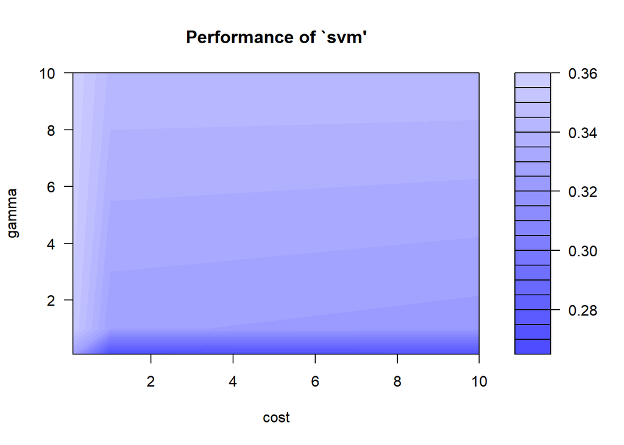

```r
plot(tune.out2)
```

```r
ypred <- predict(tune.out2$best.model,newdata=data_train)
confusionMatrix(ypred,data_train$airline_sentiment)
```

```
## Confusion Matrix and Statistics
##
##           Reference
## Prediction negative neutral positive
##   negative     3021     479      211
##   neutral        64     500       85
##   positive       45      78      517
##
## Overall Statistics
##
##                Accuracy : 0.8076
##                  95% CI : (0.7964, 0.8184)
##     No Information Rate : 0.626
##     P-Value [Acc > NIR] : < 2.2e-16
##
##                   Kappa : 0.605
##
##  Mcnemar's Test P-Value : < 2.2e-16
##
## Statistics by Class:
##
##                      Class: negative Class: neutral Class: positive
## Sensitivity                   0.9652         0.4730          0.6359
## Specificity                   0.6310         0.9622          0.9706
## Pos Pred Value                0.8141         0.7704          0.8078
## Neg Pred Value                0.9154         0.8720          0.9321
## Prevalence                    0.6260         0.2114          0.1626
## Detection Rate                0.6042         0.1000          0.1034
## Detection Prevalence          0.7422         0.1298          0.1280
## Balanced Accuracy             0.7981         0.7176          0.8033
```

**Random forest algorithm 사용(일반적으로 random forest가 decision tree보다 성능이 좋기 때문에 decision tree 생략함)**

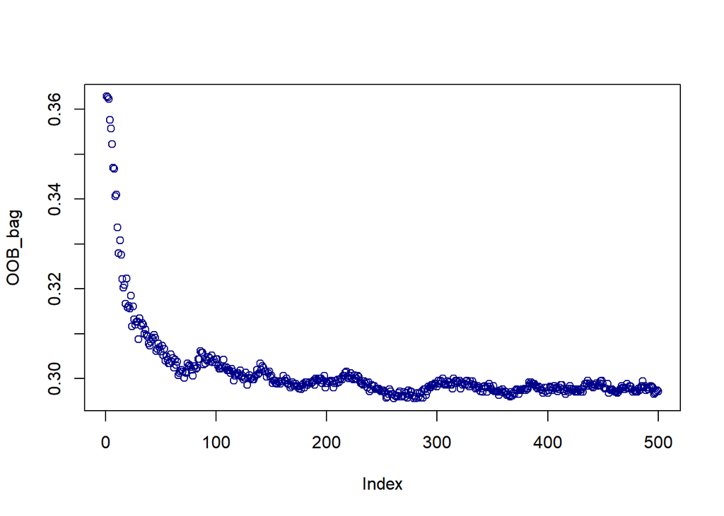

```r
#training set에 bagging 적용
set.seed(123)
bag <- randomForest(airline_sentiment~.,data=data_train,mtry=330)

#tree 개수에 따른 bagging model의 out-of-bag MSE 계산
OOB_bag <-bag$err.rate[,"OOB"]
plot(OOB_bag,col="darkblue")
```

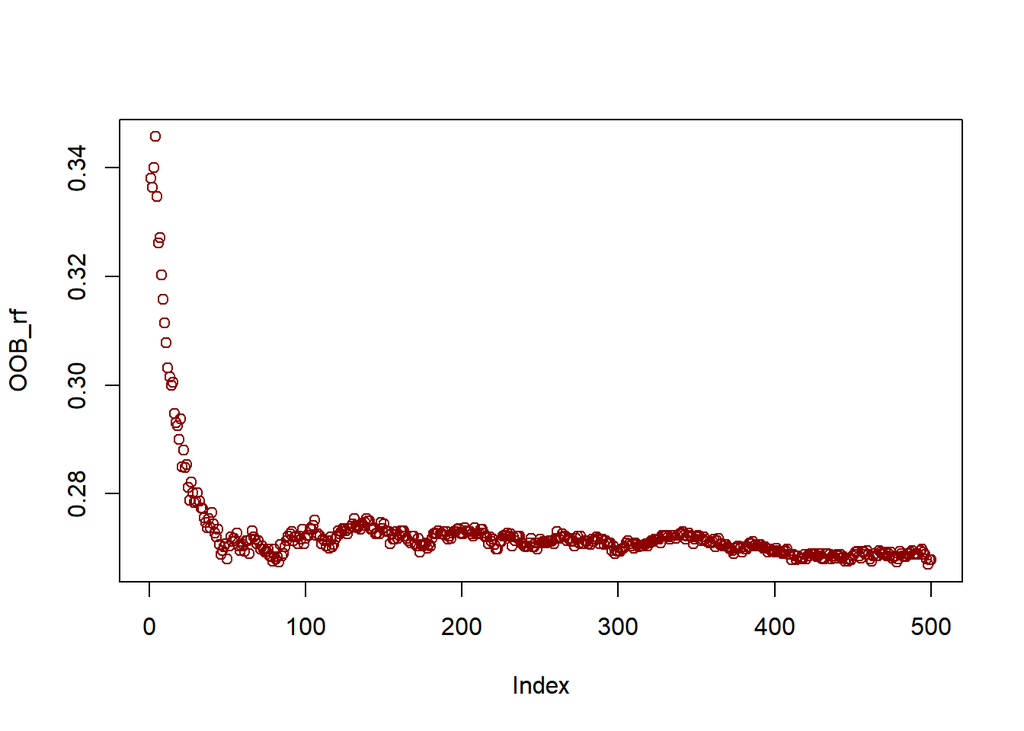

```r
#random forest 생성
set.seed(123)
rf_class <- randomForest(airline_sentiment~.,data=data_train)

#plot
OOB_rf<-rf_class$err.rate[,"OOB"]
plot(OOB_rf,col="darkred")
```

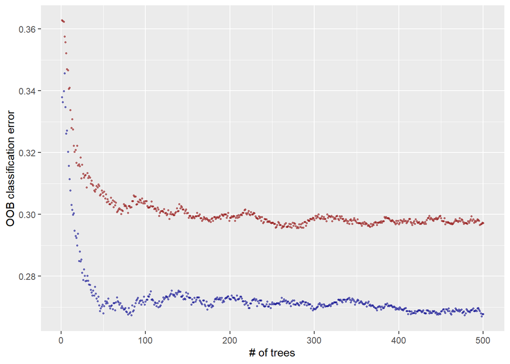

```r
# 두 그래프 비교
plot_data <- data.frame(x=1:500, bag=OOB_bag, rf=OOB_rf)
ggplot(plot_data, aes(x=x)) + geom_point(aes(y=bag), color="darkred", alpha=0.5, size=0.5) + geom_point(aes(y=rf), color="darkblue", alpha=0.5, size=0.5) + labs(x="# of trees", y="OOB classification error")
```

```r
pred_bag <- predict(bag,newdata=data_train,type="class")
cf<-confusionMatrix(pred_bag,data_train$airline_sentiment)
cf
```

```
## Confusion Matrix and Statistics
##
##           Reference
## Prediction negative neutral positive
##   negative     3120      43       18
##   neutral         7     989       22
##   positive        3      25      773
##
## Overall Statistics
##
##                Accuracy : 0.9764
##                  95% CI : (0.9718, 0.9804)
##     No Information Rate : 0.626
##     P-Value [Acc > NIR] : < 2.2e-16
##
##                   Kappa : 0.9557
##
##  Mcnemar's Test P-Value : 5.009e-08
##
## Statistics by Class:
##
##                      Class: negative Class: neutral Class: positive
## Sensitivity                   0.9968         0.9357          0.9508
## Specificity                   0.9674         0.9926          0.9933
## Pos Pred Value                0.9808         0.9715          0.9650
## Neg Pred Value                0.9945         0.9829          0.9905
## Prevalence                    0.6260         0.2114          0.1626
## Detection Rate                0.6240         0.1978          0.1546
## Detection Prevalence          0.6362         0.2036          0.1602
## Balanced Accuracy             0.9821         0.9642          0.9721
```

**Random forest bagging model을 TF-IDF 적용했을 때와 비교**

```r
dat_tfidf <- weightTfIdf(dat_dtm)

#전체 documnet 중에 0.5% 미만의 document에서 발생하는 단어는 제외
dat_tfidf2 <- removeSparseTerms(dat_tfidf,0.995)
dat_tfidf2
```

```
## <<DocumentTermMatrix (documents: 14640, terms: 330)>>
## Non-/sparse entries: 90846/4740354
## Sparsity           : 98%
## Maximal term length: 17
## Weighting          : term frequency - inverse document frequency (normalized) (tf-idf)
```

```r
#preprocessing 끝난 dtm을 데이터프레임으로 변환
data2 <- data.frame(as.matrix(dat_tfidf2))

#feature 이름 적당한 형태로 조정
colnames(data2) <- make.names(colnames(data2))

#target 변수 추가
data2$airline_sentiment <-dat$airline_sentiment
str(data2)
```

```
## 'data.frame':    14640 obs. of  331 variables:
##  $ X.jetblu         : num  0 0 0 0 0 0 0 0 0 0 ...
##  $ abl              : num  0 0 0 0 0 0 0 0 0 0 ...
##  $ account          : num  0 0 0 0 0 0 0 0 0 0 ...
##  $ actual           : num  0 0 0 0 0 0 0 0 0 0 ...
##  $ add              : num  0 0 0 0 0 0 0 0 0 0 ...
##  $ agent            : num  0 0 0 0 0 0 0 0 0 0 ...
##  $ ago              : num  0 0 0 0 0 0 0 0 0 0 ...
##  $ air              : num  0 0 0 0 0 0 0 0 0 0 ...
##  $ airlin           : num  0 0 0 0 0 0 0 0 0 0 ...
##  $ airport          : num  0 0 0 0 0 0 0 0 0 0 ...
##  $ airway           : num  0 0 0 0 0 0 0 0 0 0 ...
##  $ allow            : num  0 0 0 0 0 0 0 0 0 0 ...
##  $ almost           : num  0 0 0 0 0 0 0 0 0 0 ...
##  $ alreadi          : num  0 0 0 0 0 0 0 0 0 0 ...
```

[output cut: 86 more lines]

```r
#데이터셋 분할
data2_train <- data2[1:5000,]
data2_test <- data2[5001:14640,]

#training set에 bagging 적용
set.seed(123)
bag2 <- randomForest(airline_sentiment~.,data=data2_train,mtry=330)

#accuracy 비교
pred_bag2 <- predict(bag2,newdata=data2_train,type="class")
cf2<-confusionMatrix(pred_bag2,data2_train$airline_sentiment)
cf2
```

```
## Confusion Matrix and Statistics
##
##           Reference
## Prediction negative neutral positive
##   negative     3125      35       12
##   neutral         4    1006       11
##   positive        1      16      790
##
## Overall Statistics
##
##                Accuracy : 0.9842
##                  95% CI : (0.9803, 0.9875)
##     No Information Rate : 0.626
##     P-Value [Acc > NIR] : < 2.2e-16
##
##                   Kappa : 0.9704
##
##  Mcnemar's Test P-Value : 1.295e-07
##
## Statistics by Class:
##
##                      Class: negative Class: neutral Class: positive
## Sensitivity                   0.9984         0.9518          0.9717
## Specificity                   0.9749         0.9962          0.9959
## Pos Pred Value                0.9852         0.9853          0.9789
## Neg Pred Value                0.9973         0.9872          0.9945
## Prevalence                    0.6260         0.2114          0.1626
## Detection Rate                0.6250         0.2012          0.1580
## Detection Prevalence          0.6344         0.2042          0.1614
## Balanced Accuracy             0.9866         0.9740          0.9838
```

**-결과해석**  
지금까지의 모델은 DTM을 적용했을 때의 accuracy를 계산한 것이다. DTM 을 적용했을 때와 TF-IDF을 적용했을 때 무엇이 더 우수할까를 비교하기 위해 최종 선택된 bagging 모델의 데이터를 TF-IDF를 적용한 데이터로 교체하여 accuracy를 비교하여 준다. TF-IDF을 적용했을 때의 confusion matrix 결과 accuracy가 0.9842로 DTM을 적용했을 때보다 정확도가 높음을 확인할 수 있다. 따라서 bagging 모델에 TF-IDF를 적용한 모델을 최종 선택해준다.

#### B) 최종적으로 선택한 모델은 무엇이며 test set에 대한 accuracy는 얼마인가? –> 최종 선택 : Random Forest bagging 모델 TF_IDF 적용했을 때

```r
pred_bag_f <- predict(bag2,newdata=data2_test,type="class")
confusionMatrix(pred_bag_f,data2_test$airline_sentiment)
```

```
## Confusion Matrix and Statistics
##
##           Reference
## Prediction negative neutral positive
##   negative     3052     438      148
##   neutral      2266    1294      381
##   positive      730     310     1021
##
## Overall Statistics
##
##                Accuracy : 0.5567
##                  95% CI : (0.5468, 0.5667)
##     No Information Rate : 0.6274
##     P-Value [Acc > NIR] : 1
##
##                   Kappa : 0.3098
##
##  Mcnemar's Test P-Value : <2e-16
##
## Statistics by Class:
##
##                      Class: negative Class: neutral Class: positive
## Sensitivity                   0.5046         0.6337          0.6587
## Specificity                   0.8369         0.6516          0.8714
## Pos Pred Value                0.8389         0.3283          0.4954
## Neg Pred Value                0.5008         0.8687          0.9302
## Prevalence                    0.6274         0.2118          0.1608
## Detection Rate                0.3166         0.1342          0.1059
## Detection Prevalence          0.3774         0.4088          0.2138
## Balanced Accuracy             0.6707         0.6427          0.7651
```

**-결과해석**  
test set에 대해 confusion matrix를 만들어 accuracy를 구해본 결과 정확도가 0.5567로 train했을때의 정확도에 비해 크게 뒤떨어짐을 알 수 있다.

#### C) 세 class(positive,negative,neutral)중에서 어떤 class를 분류하기 어려운가? -> negative 분류어려움

**-결과해석**  
confusion matrix에서 세가지 class의 sensitivity를 비교했을 때 negative class의 sensitivity가 0.5046으로 가장 낮음을 알 수 있다. 따라서 negative class의 분류가 가장 어렵다.